# 727 HW 5

Makenna Harrison

2023-11-25

github: https://github.com/makharrison/727_hw5

```r
library(censusapi)
library(tidyverse)
library(magrittr)
library(factoextra)
library(ggmap)
library(ggalt)
```

Using censusapi, we can pull the desired data as follows:

```r
acs_il_c <- getCensus(name = "acs/acs5",
 vintage = 2016,
 vars = c("NAME", "B01003_001E", "B19013_001E", "B19301_001E"),
 region = "county:*",
 regionin = "state:17",
 key = cs_key) %>%
 rename(pop = B01003_001E,
 hh_income = B19013_001E,
 income = B19301_001E)
 head(acs_il_c)
```

```
##   state county                       NAME    pop hh_income income
## 1    17    067   Hancock County, Illinois  18633     50077  25647
## 2    17    063    Grundy County, Illinois  50338     67162  30232
## 3    17    091  Kankakee County, Illinois 111493     54697  25111
## 4    17    043    DuPage County, Illinois 930514     81521  40547
## 5    17    003 Alexander County, Illinois   7051     29071  16067
## 6    17    129    Menard County, Illinois  12576     60420  31323
```

Additionally, we can pull map data for counties in IL.

```r
 il_map <- map_data("county", region = "illinois")
 head(il_map)
```

```
##        long      lat group order   region subregion
## 1 -91.49563 40.21018     1     1 illinois     adams
## 2 -90.91121 40.19299     1     2 illinois     adams
## 3 -90.91121 40.19299     1     3 illinois     adams
## 4 -90.91121 40.10704     1     4 illinois     adams
## 5 -90.91121 39.83775     1     5 illinois     adams
## 6 -90.91694 39.75754     1     6 illinois     adams
```

Next, we can join the two frames together.

```r
acs_il_c <- acs_il_c %>%
  mutate(county_clean = tolower(NAME),
         county_clean = gsub(" county, illinois","",county_clean))
```

```r
acs_map <- merge(acs_il_c,il_map,by.x="county_clean",by.y="subregion")
```

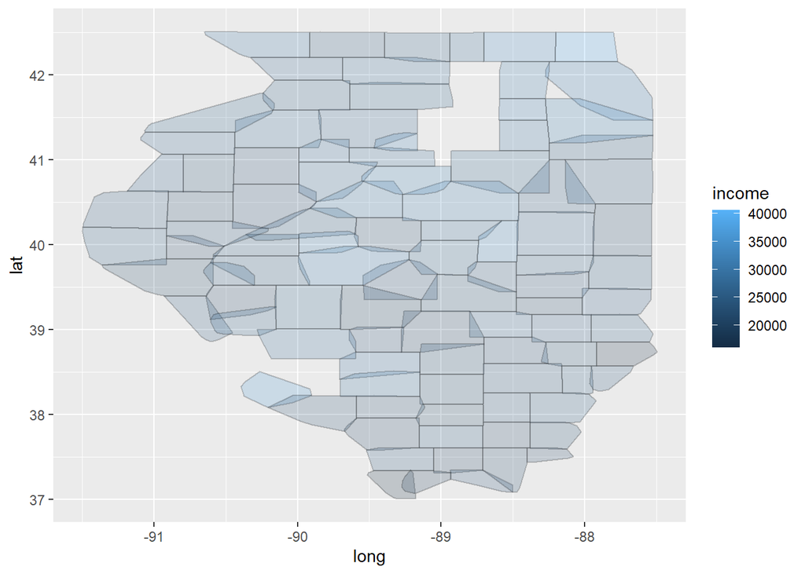

```r
 ggplot(acs_map) +
 geom_encircle(aes(x = long, y = lat, group = group, fill = income), s_shape = 1, expand = 0,
                alpha = 0.2, color = "black", show.legend = TRUE)
```

Next, we can perform hierarchical clustering.

```r
acs_map_clean <- acs_map %>%
  select(pop,hh_income,income) %>%
  distinct()
```

First, we create the distance matrix

```r
hclust_d <- dist(acs_map_clean)
```

Next, we cluster using the ward method.

```r
hc_ward <- hclust(hclust_d, method = "ward.D2")
```

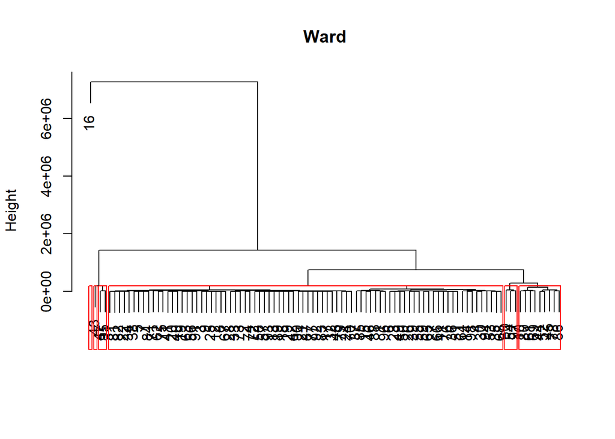

```r
plot(hc_ward, main = "Ward", xlab = "", sub = "")
rect.hclust(hc_ward,
            k = 6,
            border = "red")
```

There looks to be 6 clusters

```r
cutree(hc_ward, 6)
```

```
##  [1] 1 1 1 1 1 1 1 1 1 2 1 1 1 1 1 3 1 1 1 1 1 1 1 1 1 1 1 1 1 1 1 1 1 1 1 1 1 1
## [39] 1 1 1 1 4 2 2 1 5 1 1 1 1 2 1 6 1 1 1 1 1 6 2 1 1 1 1 1 1 1 2 1 1 1 1 1 1 1
## [77] 1 2 1 2 1 1 1 1 1 2 1 1 1 1 1 1 1 1 5 1 6 1
```

Next, we want to visualize these clusters. First, we need to add the clusters to a data frame.

```r
acs_map_clean2 <- acs_map %>%
  select(county_clean, pop,hh_income,income) %>%
  distinct() %>%
  mutate(cluster = cutree(hc_ward, 6)) %>%
  select(county_clean,cluster)
```

```r
acs_map_new <- merge(acs_map, acs_map_clean2,by="county_clean")
```

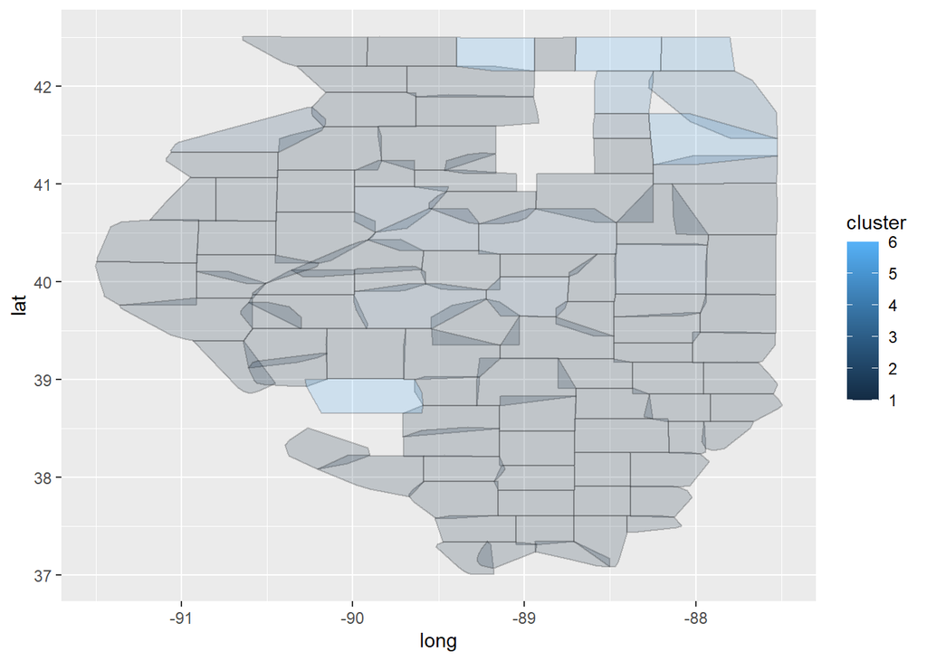

```r
 ggplot(acs_map_new) +
 #geom_polygon(aes(x = long, y = lat, group = group, fill = cluster)) +
 geom_encircle(aes(x = long, y = lat, group = group, fill = cluster), s_shape = 1, expand = 0,
                alpha = 0.2, color = "black", show.legend = TRUE)
```

Now, we look at census tracts instead of counties.

```r
acs_il_t <- getCensus(name = "acs/acs5",
vintage = 2016,
vars = c("NAME", "B01003_001E", "B19013_001E", "B19301_001E"),
region = "tract:*",
regionin = "state:17",
key = cs_key) %>%
mutate_all(list(~ifelse(.==-666666666, NA, .))) %>%
rename(pop = B01003_001E,
hh_income = B19013_001E,
income = B19301_001E)
head(acs_il_t)
```

```
##   state county  tract                                        NAME  pop
## 1    17    031 806002 Census Tract 8060.02, Cook County, Illinois 7304
## 2    17    031 806003 Census Tract 8060.03, Cook County, Illinois 7577
## 3    17    031 806400    Census Tract 8064, Cook County, Illinois 2684
## 4    17    031 806501 Census Tract 8065.01, Cook County, Illinois 2590
## 5    17    031 750600    Census Tract 7506, Cook County, Illinois 3594
## 6    17    031 310200    Census Tract 3102, Cook County, Illinois 1521
##   hh_income income
## 1     56975  23750
## 2     53769  25016
## 3     62750  30154
## 4     53583  20282
## 5     40125  18347
## 6     63250  31403
```

Let’s clean the data for kmeans clustering.

```r
acs_il_t_clean <- acs_il_t%>%
  select(NAME,pop,hh_income,income,county) %>%
  distinct() %>%
  na.omit() %>%
  select(pop,hh_income,income)
```

Since we want to use K Means in this section, we start by determining the optimal number of K that results in Clusters with low within but high between variation. Plot within cluster sums of squares for a range of K (e.g. up to 20).

The total within sum of squares is lower for larger values of k. Based on the plot, the elbow of the curve appears at k = 3.

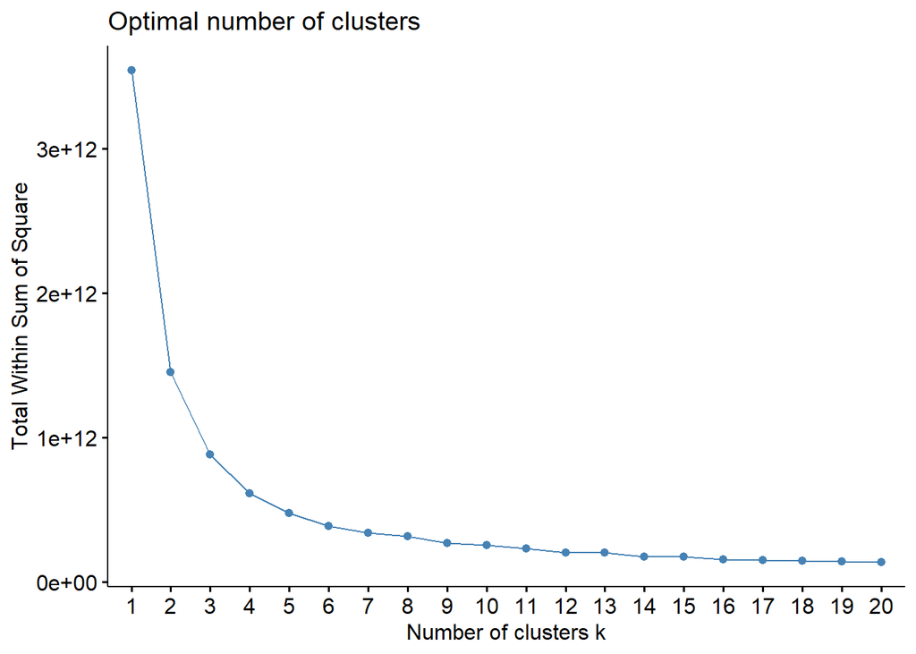

```r
fviz_nbclust(acs_il_t_clean, #data set we want to use
             kmeans, #cluster method
             method = "wss", #method used for estimating the optimal number of clusters
             k.max = 20)
```

```r
km_1 <- kmeans(acs_il_t_clean, 3, nstart = 20)
```

```r
acs_il_t_clean <- acs_il_t_clean %>%
  mutate(cluster = km_1$cluster)
```

The means for each cluster:

```r
km_1$centers
```

```
##        pop hh_income   income
## 1 3665.401  39382.67 20507.19
## 2 4437.356 122378.74 62174.49
## 3 4637.467  72015.19 34810.54
```

The most frequent counties for each cluster:

```r
acs_il_t_clean2 <- acs_il_t%>%
  select(NAME,pop,hh_income,income,county) %>%
  distinct() %>%
  na.omit() %>%
  mutate(cluster = acs_il_t_clean$cluster)
```

county 031 (Cook County) appears the most times for each of the three clusters.

```r
acs_il_t_clean2 %>%
  group_by(cluster) %>%
  count(county) %>%
  arrange(desc(n)) %>%
  head(3) %>%
  arrange(cluster)
```

```
## # A tibble: 3 × 3
## # Groups:   cluster [3]
##   cluster county     n
##     <int> <chr>  <int>
## 1       1 031      717
## 2       2 031      165
## 3       3 031      430
```

Alternatively, we could write a look for calculate kmeans for each value of k:

```r
clusters <- lapply(1:10, function(i) kmeans(acs_il_t_clean, i, nstart = 20))
```

Additionally, we can see which cluster each tract would fall into for differing values of k.

```r
acs_il_t_clean %>%
  mutate(
    cluster1 = clusters[[1]]$cluster,
    cluster2 = clusters[[2]]$cluster,
    cluster3 = clusters[[3]]$cluster,
    cluster4 = clusters[[4]]$cluster,
    cluster5 = clusters[[5]]$cluster,
    cluster6 = clusters[[6]]$cluster,
    cluster7 = clusters[[7]]$cluster,
    cluster8 = clusters[[8]]$cluster,
    cluster9 = clusters[[9]]$cluster,
    cluster10 = clusters[[10]]$cluster
  ) %>%
  head()
```

```
##    pop hh_income income cluster cluster1 cluster2 cluster3 cluster4 cluster5
## 1 7304     56975  23750       1        1        2        1        4        3
## 2 7577     53769  25016       1        1        2        1        4        3
## 3 2684     62750  30154       3        1        2        3        4        3
## 4 2590     53583  20282       1        1        2        1        4        3
## 5 3594     40125  18347       1        1        2        1        2        4
## 6 1521     63250  31403       3        1        2        3        4        3
##   cluster6 cluster7 cluster8 cluster9 cluster10
## 1        3        2        8        5         4
## 2        2        7        8        2         2
## 3        3        2        8        5         4
## 4        2        7        8        2         2
## 5        2        7        4        6        10
## 6        3        2        8        5         4
```